# Climate and Agriculture: Prerequisites

Author

Christina Deodatis

Published

May 19, 2025

## Prerequisites

[NASA EarthData account](https://urs.earthdata.nasa.gov/users/new)

The Earth Science Data Systems (ESDS) program offers comprehensive and unrestricted access to NASA’s extensive collection of Earth science data, facilitating a deeper understanding of our planet.

### Accounts

[Google Earth Engine](https://earthengine.google.com/): You will need a Google account to access Google Earth Engine. If you do not have one, please follow the steps below to create one.

### Setting up your Google Earth Engine Account

Google Earth Engine is free for non-commercial use. In order to access and run the code we will be working with below in the code editor, you must create an account. Upon launching the project (click [here](https://code.earthengine.google.com/6fb536d4819b9d27551094f6ed3a8b52)), you will be prompted with the following message:

[figure not shown]

Select “I want to register a project”, which will lead you to a welcome page. Here, navigate to the configuration section on the left side.

[figure not shown]

In the configuration section, you will be asked to register for commercial use or check if you are eligible for non-commercial use. Get started with registering for a non-commercial account.

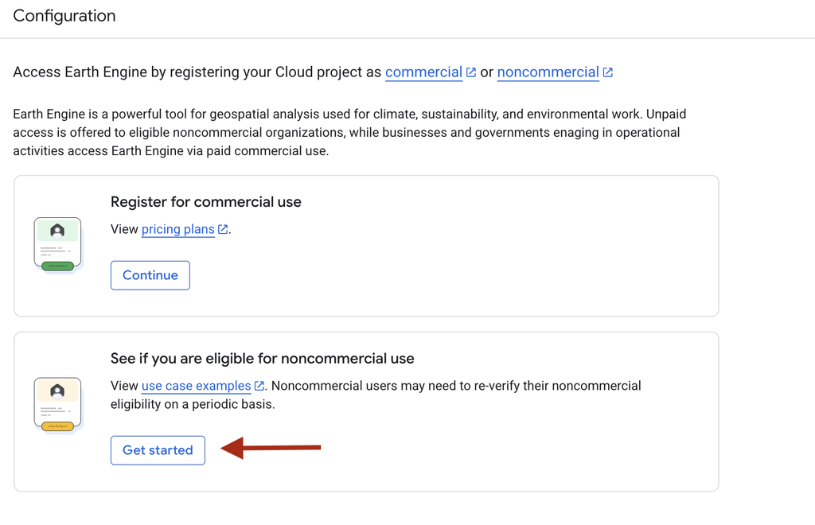

You will be asked to fill out a series of questions. Register as an independent user or how you see fit for your own Google Earth Engine use.

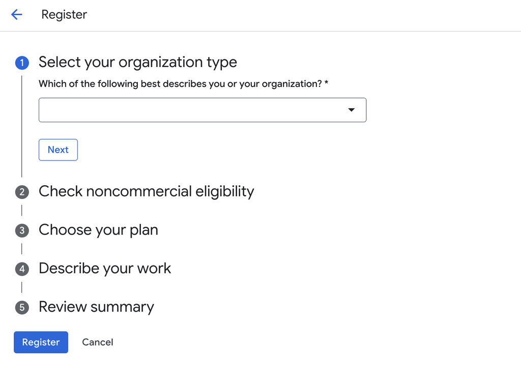

After submitting, you should find a message that you have been registered for non-commercial use. You will be able to open the project now.

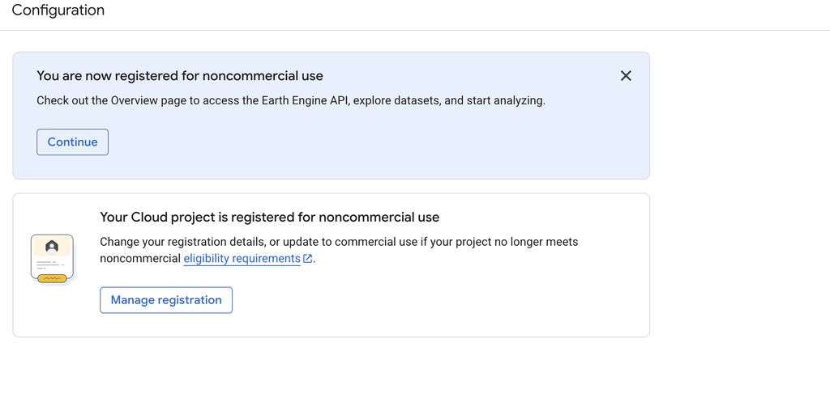